# CRAN EDA

## 1 Introduction

```r
library(tidyverse)
library(RMySQL)
library(treemapify)
library(corrplot)
library(ggthemes)
library(pander)
library(ggwes)
library(knitr)
library(kableExtra)
```

## 2 File List

### 2.1 Input Files

- cran: Full CRAN Database as of Septmeber 2023 with selected metadata
- cran_repos: CRAN GitHub repos loaded from database containing repository metrics

```r
cran <- dbReadTable(con, "package_database")

cran_repos <- dbReadTable(con, "package_repo_info")
```

## 3 Exploratory Data Analysis (EDA) of All R Packages on CRAN

This section contains an initial exploratory data analysis on the CRAN database, including the number of dependencies per package, the number of authors per package, number of reverse dependencies per package, and the download data for some of the top packages.

### 3.1 Count Data for Dependencies, Authors, and Reverse Dependencies

```r
# Writing loop to count number of authors and dependencies across packages
Count_Data <- seq_len(nrow(cran)) %>%
  map_df(~{
    cran[.x, ] %>%
      select(Package, Depends, Author, Reverse_Depends) %>%
      map_df(~ifelse(is.na(.x), 0, length(str_split(.x, ",")[[1]]))) %>% ### Count objects separated by commas
      mutate(Package = cran$Package[.x])
  }) %>%
  select(Package, Author, Depends, Reverse_Depends)

colnames(Count_Data) <- c("Package", "Author_Count", "Depends_Count",
                          "Reverse_Depends_Count")

### Join the count variables
cran <- cran %>% left_join(Count_Data, by = "Package")

# Modify the author count to detect those with "and" and no commas as 2 authors, and count changed observations changed
cran <- cran %>%
  # Step 1: Create a new variable to record the previous Author_Count
  mutate(Previous_Author_Count = Author_Count) %>%
  # Step 2: Modify the Author_Count
  mutate(Author_Count = ifelse(str_detect(Author, "\\band\\b") & !str_detect(Author, ","), 2, Author_Count)) %>%
  # Step 3: Create a new variable to indicate if the Author_Count was changed
  mutate(Changed = ifelse(Author_Count != Previous_Author_Count, 1, 0))
```

#### 3.1.1 Dependencies per Package

We will visualize the dependencies counts by creating numeric ranges and storing it in a factor variable. The factor categories are calculated using the “jenks” method, which tries to minimize the variance within factor categories and maximize the variance between factor categories. We output the table to construct percentage counts per category.

```r
### Creating categories for dependency counts

cran <- cran %>%
          mutate(Depends_Cat = case_when(Depends_Count == 0 ~ "0",
                                         Depends_Count  == 1 ~ "1",
                                         Depends_Count  == 2 ~ "2",
                                         Depends_Count  == 3 | Depends_Count == 4 ~ "3-4",
                                         Depends_Count  > 4 ~ "5-15"))
## converting to factor
cran$Depends_Cat <- as.factor(cran$Depends_Cat)

# Getting counts per category
table(cran$Depends_Cat)
```

```
    0     1     2   3-4  5-15
 5210 10304  1985  1645   708
```

A little more than half of the packages 1 dependency, 26% have 0 dependencies listed, 10% have 2 dependencies, 8% have 3 to 4 dependencies, and 4% have 5 or more dependencies.

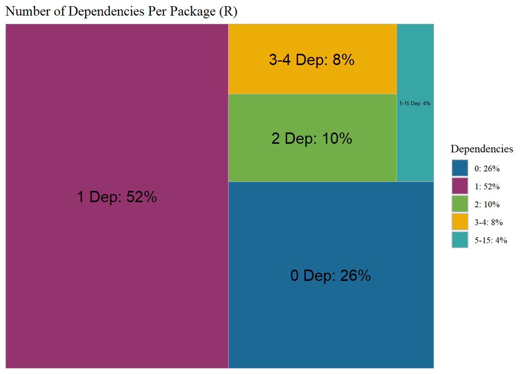

```r
### Creating inputs for tree map plot

Dependencies <- c("0: 26%", "1: 52%", "2: 10%", "3-4: 8%", "5-15: 4%")

Value <- c(26, 52, 10, 8, 4)

Label <- c("0 Dep: 26%", "1 Dep: 52%", "2 Dep: 10%", "3-4 Dep: 8%", "5-15 Dep: 4%")

Depends_Tree <- cbind(Dependencies, Value, Label)

Depends_Tree <- as.data.frame(Depends_Tree)

Depends_Tree$Value <- as.numeric(Depends_Tree$Value)

### Generating tree map plot

ggplot(Depends_Tree, aes(area = Value, fill = Dependencies, label = Label)) +
  geom_treemap() +
  geom_treemap_text(colour = "black",
                    place = "centre",
                    size = 15)+
  ggtitle("Number of Dependencies Per Package (R)")+
  scale_fill_westat(option = "BLUES")+
  theme_tufte()+
  theme(legend.position = "right")
```

#### 3.1.2 Authors per Package

Again, we do the same thing for authors that we did for dependencies, but instead of using the “jenks” method to determine breaks, we create factor categories based on single authors (1), smaller groups (2-5), medium sized groups (6-9), and large groups (10+). We are more concerned with the size of the group rather than trying to minimize variance within the separate groups for authors

```r
### Creating categories for numeric ranges
cran <- cran %>%
         mutate(Authors_Cat = case_when(
                                         Author_Count == 1 ~ "1",
                                         Author_Count > 1 & Author_Count < 6 ~ "2-5",
                                         Author_Count > 5 & Author_Count < 10 ~ "6-9",
                                         Author_Count > 9  ~ "10+"))


### Assigning categorical variables to class factor and reordering
cran$Authors_Cat <- factor(cran$Authors_Cat, levels = c("1", "2-5", "6-9", "10+"))

### getting counts per category
table(cran$Authors_Cat)
```

```
    1   2-5   6-9   10+
 7743 10265  1307   537
```

39% of packages have only one author, 52% have 2-5, 6% have 6-9, and only 3% have 10+ authors

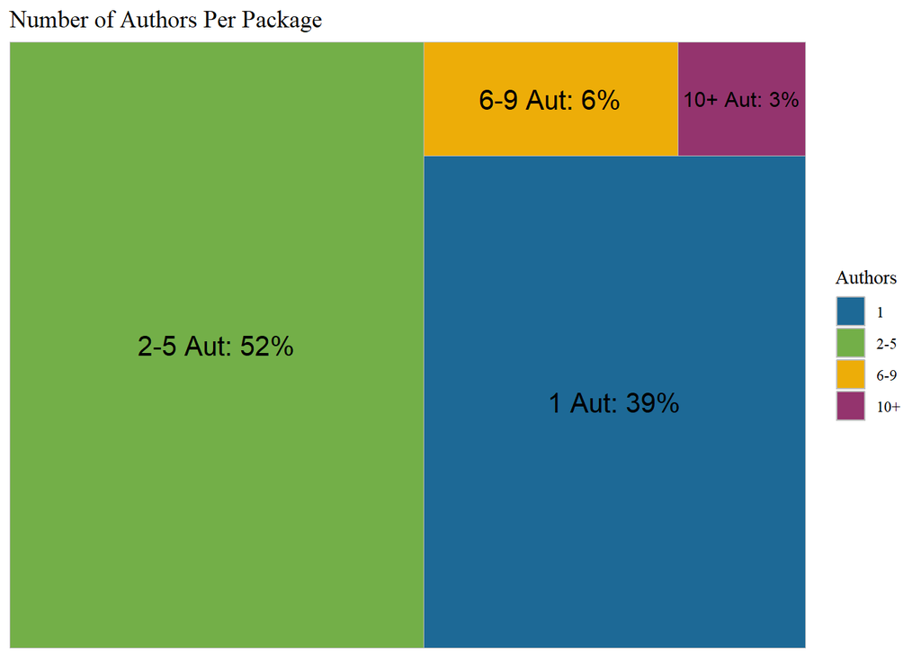

```r
### Creating inputs for tree map plot

Authors <- c("1", "2-5", "6-9", "10+")

Value <- c(39, 52, 6, 3)

Label <- c("1 Aut: 39%", "2-5 Aut: 52%", "6-9 Aut: 6%", "10+ Aut: 3%")

Authors_Tree <- cbind(Authors, Value, Label)

Authors_Tree <- as.data.frame(Authors_Tree)

Authors_Tree$Value <- as.numeric(Authors_Tree$Value)


ggplot(Authors_Tree, aes(area = Value, fill = Authors, label = Label)) +
  geom_treemap() +
  geom_treemap_text(colour = "black",
                    place = "centre",
                    size = 15)+
  ggtitle("Number of Authors Per Package")+
  scale_fill_westat(option = "BLUES", breaks = c("1", "2-5", "6-9", "10+"))+
  theme_tufte()
```

#### 3.1.3 Reverse Dependencies per Package

```r
### Creating categories for numeric ranges
cran <- cran %>%
         mutate(Reverse_Depends_Cat = case_when(

Reverse_Depends_Count > 0 & Reverse_Depends_Count < 4 ~ "1-3",

Reverse_Depends_Count > 3 & Reverse_Depends_Count < 9 ~ "4-8",

Reverse_Depends_Count > 8 & Reverse_Depends_Count < 20 ~ "9-19",

Reverse_Depends_Count > 19 ~ "20+",


))

### Assigning categorical variables to class factor
cran$Reverse_Depends_Cat <- as.factor(cran$Reverse_Depends_Cat)

### getting counts per category
table(cran$Reverse_Depends_Cat)
```

```
 1-3  20+  4-8 9-19
1262   81  211   90
```

Of the packages that have at least one reverse dependency, 77% have 1 to 3, 13% have 4 to 8, 5% have 9 to 19 and 5% have 20+. Recall that only 8% of the packages have any reverse dependencies to begin with.

[figure not shown]

```r
### Creating inputs for tree map plot

Rev_Dep <- c("0: 92%", "1-3: 6%", "4-10: 1%", "11+: 1%")

Value <- c(80, 6, 2, 2)

Label <- c("0: 92%", "1-3: 6%", "4-10: 1%", "11+: 1%")

Reverse_Depends_Tree <- cbind(Rev_Dep, Value, Label)

Reverse_Depends_Tree <- as.data.frame(Reverse_Depends_Tree)

Reverse_Depends_Tree$Value <- as.numeric(Reverse_Depends_Tree$Value)

ggplot(Reverse_Depends_Tree, aes(area = Value, fill = Rev_Dep, label = Label)) +
  geom_treemap() +
  geom_treemap_text(colour = "black",
                    place = "centre",
                    size = 15)+
  ggtitle("Number of Reverse Dependencies Per Package (R)")+
  scale_fill_westat(option = "BLUES", breaks = c("0: 92%", "1-3: 6%", "4-10: 1%", "11+: 1%"))+
  theme_tufte()+
  theme(legend.position = "right")
```

### 3.2 Download Data

#### 3.2.1 Number of Downloads

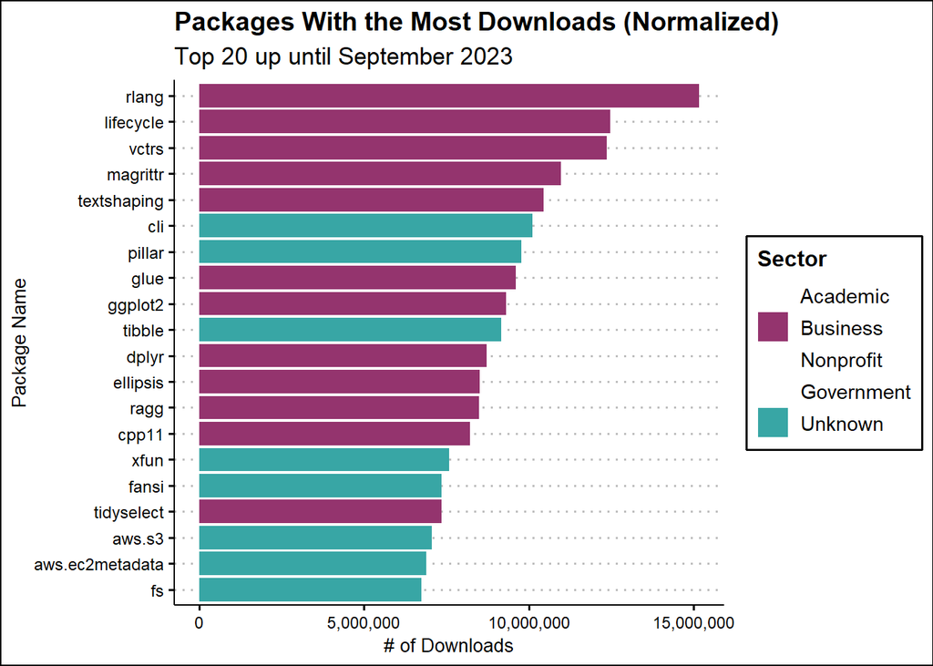

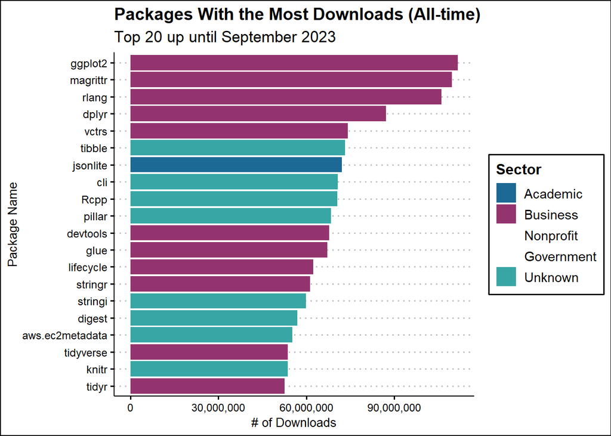

```r
# replaces NAs with Unknown for graph output
cran$Sector[is.na(cran$Sector)] <- "Unknown"


all_possible_sectors <- c("Academic", "Business", "Nonprofit", "Government", "Unknown")

# Use the factor levels from the main 'cran' dataframe
cran$Sector <- factor(cran$Sector, levels = all_possible_sectors)

#-------------------------------------------------------------------------

### Getting the top 20 downloaded packages
 Top_20_Downloads_Normalized <-  cran %>%
  top_n(20, Downloads_Normalized)

  Top_20_Downloads_Normalized$Package <- factor(Top_20_Downloads_Normalized$Package,
                           levels = Top_20_Downloads_Normalized$Package[order(Top_20_Downloads_Normalized$Downloads_Normalized)])

# Ensure that the Sector variable in your data frame has all these levels
Top_20_Downloads_Normalized$Sector <- factor(Top_20_Downloads_Normalized$Sector, levels = all_possible_sectors)

# plot the top 20
  Top_20_Downloads_Normalized %>%
ggplot(aes(x = Package, y = as.numeric(Downloads_Normalized), fill = Sector))+
    geom_bar(stat = "identity")+
    coord_flip()+
  ggtitle(label = "Packages With the Most Downloads (Normalized)",
          subtitle = "Top 20 up until September 2023")+
  xlab("Package Name")+
  ylab("# of Downloads")+
    scale_y_continuous(labels = scales::comma)+
    scale_fill_westat(option = "BLUES", drop = FALSE)+
    theme_clean()

 #------------------------------------------------------------------------

### Getting the top 20 downloaded packages
 Top_20_Downloads_AT <-  cran %>%
  top_n(20, Downloads_All_Time)

  Top_20_Downloads_AT$Package <- factor(Top_20_Downloads_AT$Package,
                           levels = Top_20_Downloads_AT$Package[order(Top_20_Downloads_AT$Downloads_All_Time)])


# Ensure that the Sector variable in your data frame has all these levels
Top_20_Downloads_AT$Sector <- factor(Top_20_Downloads_AT$Sector, levels = all_possible_sectors)

# plot the top 20
  Top_20_Downloads_AT %>%
ggplot(aes(x = Package, y = as.numeric(Downloads_All_Time), fill = Sector))+
    geom_bar(stat = "identity")+
    coord_flip()+
  ggtitle(label = "Packages With the Most Downloads (All-time)",
          subtitle = "Top 20 up until September 2023")+
  xlab("Package Name")+
  ylab("# of Downloads")+
    scale_y_continuous(labels = scales::comma)+
    scale_fill_westat(option = "BLUES", drop = FALSE)+
    theme_clean()
```

#### 3.2.2 Title Descriptions for Most Downloads

Here, we get some insight on what these top 20 packages are used for. It appears organization of data, visualizing data, and cleaning data are some of the key highlights from the top downloaded packages.

```r
Top_20_Downloads_Normalized %>%
  select(Package, Sector, Title, Downloads_Normalized)%>%
  arrange(desc(Downloads_Normalized))%>%
  kbl(caption = "Title Descriptions for the Most Downloaded Packages (Normalized)")%>%
  kable_classic()%>%
  kable_styling(font_size = 12,  full_width = T)%>%
 row_spec(0, bold = T, background = westat_blue(), color = "white")%>%
  column_spec(1:3, border_right = T)%>%
  scroll_box()
```

Title Descriptions for the Most Downloaded Packages (Normalized)

|  | Package | Sector | Title | Downloads_Normalized |
| --- | --- | --- | --- | --- |
| 14863 | rlang | Business | Functions for Base Types and Core R and 'Tidyverse' Features | 15157282 |
| 9038 | lifecycle | Business | Manage the Life Cycle of your Package Functions | 12466319 |
| 19149 | vctrs | Business | Vector Helpers | 12354349 |
| 9481 | magrittr | Business | A Forward-Pipe Operator for R | 10969342 |
| 18181 | textshaping | Business | Bindings to the 'HarfBuzz' and 'Fribidi' Libraries for Text Shaping | 10439215 |
| 2404 | cli | Unknown | Helpers for Developing Command Line Interfaces | 10113083 |
| 12645 | pillar | Unknown | Coloured Formatting for Columns | 9766738 |
| 6782 | glue | Business | Interpreted String Literals | 9597283 |
| 6555 | ggplot2 | Business | Create Elegant Data Visualisations Using the Grammar of Graphics | 9302718 |
| 18259 | tibble | Unknown | Simple Data Frames | 9155589 |
| 4191 | dplyr | Business | A Grammar of Data Manipulation | 8724160 |
| 4699 | ellipsis | Business | Tools for Working with ... | 8513327 |
| 13820 | ragg | Business | Graphic Devices Based on AGG | 8490946 |
| 3099 | cpp11 | Business | A C++11 Interface for R's C Interface | 8211148 |
| 19691 | xfun | Unknown | Supporting Functions for Packages Maintained by 'Yihui Xie' | 7575899 |
| 5275 | fansi | Unknown | ANSI Control Sequence Aware String Functions | 7345470 |
| 18329 | tidyselect | Business | Select from a Set of Strings | 7343579 |
| 822 | aws.s3 | Unknown | 'AWS S3' Client Package | 7066464 |
| 816 | aws.ec2metadata | Unknown | Get EC2 Instance Metadata | 6898427 |
| 5908 | fs | Unknown | Cross-Platform File System Operations Based on 'libuv' | 6751105 |

```r
Top_20_Downloads_AT %>%
  select(Package, Sector, Title, Downloads_All_Time)%>%
  arrange(desc(Downloads_All_Time))%>%
  kbl(caption = "Title Descriptions for the Most Downloaded Packages (All-time)")%>%
  kable_classic()%>%
  kable_styling(font_size = 12, full_width = T)%>%
 row_spec(0, bold = T, background = westat_blue(), color = "white")%>%
  column_spec(1:3, border_right = T)%>%
  scroll_box()
```

Title Descriptions for the Most Downloaded Packages (All-time)

|  | Package | Sector | Title | Downloads_All_Time |
| --- | --- | --- | --- | --- |
| 6555 | ggplot2 | Business | Create Elegant Data Visualisations Using the Grammar of Graphics | 111632612 |
| 9481 | magrittr | Business | A Forward-Pipe Operator for R | 109693420 |
| 14863 | rlang | Business | Functions for Base Types and Core R and 'Tidyverse' Features | 106100971 |
| 4191 | dplyr | Business | A Grammar of Data Manipulation | 87241601 |
| 19149 | vctrs | Business | Vector Helpers | 74126095 |
| 18259 | tibble | Unknown | Simple Data Frames | 73244712 |
| 8503 | jsonlite | Academic | A Simple and Robust JSON Parser and Generator for R | 72078171 |
| 2404 | cli | Unknown | Helpers for Developing Command Line Interfaces | 70791582 |
| 14135 | Rcpp | Unknown | Seamless R and C++ Integration | 70645651 |
| 12645 | pillar | Unknown | Coloured Formatting for Columns | 68367164 |
| 3791 | devtools | Business | Tools to Make Developing R Packages Easier | 67790088 |
| 6782 | glue | Business | Interpreted String Literals | 67180984 |
| 9038 | lifecycle | Business | Manage the Life Cycle of your Package Functions | 62331594 |
| 17629 | stringr | Business | Simple, Consistent Wrappers for Common String Operations | 61265559 |
| 17627 | stringi | Unknown | Fast and Portable Character String Processing Facilities | 59874948 |
| 3907 | digest | Unknown | Create Compact Hash Digests of R Objects | 56980817 |
| 816 | aws.ec2metadata | Unknown | Get EC2 Instance Metadata | 55187418 |
| 18349 | tidyverse | Business | Easily Install and Load the 'Tidyverse' | 53736053 |
| 8670 | knitr | Unknown | A General-Purpose Package for Dynamic Report Generation in R | 53724921 |
| 18324 | tidyr | Business | Tidy Messy Data | 52663892 |

## 4 GitHub Package EDA

For the packages on GitHub, we were able to collect some impact measures relating to repository metrics. We loaded our table from our database and visualize a few of them here.

```r
#### filtering for URLs that only contain github.com in the link
cran_github <- cran %>% filter(grepl("https://github.com", URL, ignore.case = TRUE))

### extracting the URL portion with the slug
cran_github <- cran_github %>%
          mutate(URL = str_extract(URL, "https://github.com/([^/]+)/([^/]+)"))


### removing commas
cran_github <- cran_github %>%
          mutate(URL = sub(",.*$",  "",  URL))

### extracting slug portion
cran_github <- cran_github %>%
          mutate(slug = str_extract(URL, "(?<=github.com/)[^/]+/[^/]+"))


cran_github <- cran_github %>%
          mutate(slug = str_extract(slug, "[^\\s]+/[^\\s]+"))


### creating slug for linkage
cran_repos <- cran_repos %>%
  mutate(slug = paste(owner, repo, sep = "/"))

### join to cran by Package for more data
cran_repos <- cran_github %>%
                  left_join(cran_repos, by = "slug")%>%
                  distinct(slug, .keep_all = T)


### create "year_created" variable
cran_repos$year_created <- substr(cran_repos$created_at, 1, 4)
```

### 4.1 Repository Impact Measures

#### 4.1.1 Stars

creating a categorical star count so we can visualize in a treemap plot

```r
### Creating categories for dependency counts

cran_repos <- cran_repos %>%
          mutate(Star_Cat = case_when(stargazer_count >= 0 & stargazer_count < 11 ~ "0-10",
                                         stargazer_count >= 11 &  stargazer_count < 51 ~ "11-50",
                                         stargazer_count >= 51 & stargazer_count < 200 ~ "51-199",
                                         stargazer_count >= 200 ~ "200+"))
## converting to factor
cran_repos$Star_Cat <- as.factor(cran_repos$Star_Cat)

# Getting counts per category
pander(table(cran_repos$Star_Cat))
```

| 0-10 | 11-50 | 200+ | 51-199 |
| --- | --- | --- | --- |
| 3948 | 1832 | 387 | 836 |

Over half the repositories have 0-10 stars, and only 6% have 200 or more stars

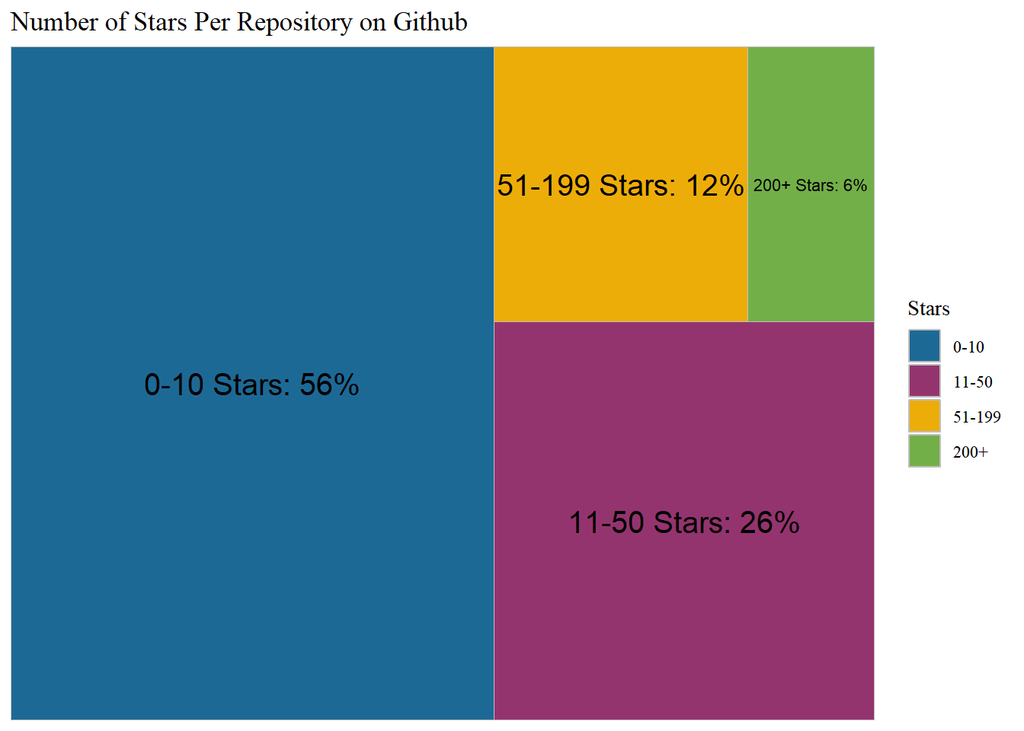

```r
### Creating inputs for tree map plot

Stars <- c("0-10", "11-50", "51-199", "200+")

Value <- c(56, 26, 12, 6)

Label <- c("0-10 Stars: 56%", "11-50 Stars: 26%", "51-199 Stars: 12%", "200+ Stars: 6%")

Stars_Tree <- cbind(Stars, Value, Label)

Stars_Tree<- as.data.frame(Stars_Tree)

Stars_Tree$Value <- as.numeric(Stars_Tree$Value)

### Generating tree map plot

ggplot(Stars_Tree, aes(area = Value, fill = Stars, label = Label)) +
  geom_treemap() +
  geom_treemap_text(colour = "black",
                    place = "centre",
                    size = 15)+
  ggtitle("Number of Stars Per Repository on Github")+
  scale_fill_westat(option = "BLUES", breaks =  c("0-10", "11-50", "51-199", "200+"))+
  theme_tufte()
```

#### 4.1.2 Fork Count

Again, creating a categorical fork count so we can visualize in a treemap plot

```r
### Creating categories for dependency counts

cran_repos <- cran_repos %>%
          mutate(Fork_Cat = case_when(fork_count >= 0 & fork_count < 2 ~ "0-1",
                                         fork_count >= 2 &  fork_count < 10 ~ "2-9",
                                         fork_count >= 10 & fork_count < 50 ~ "10-49",
                                         fork_count >= 50 ~ "50+"))
## converting to factor
cran_repos$Fork_Cat <- as.factor(cran_repos$Fork_Cat)

# Getting counts per category
pander(table(cran_repos$Fork_Cat))
```

| 0-1 | 10-49 | 2-9 | 50+ |
| --- | --- | --- | --- |
| 3129 | 1112 | 2489 | 273 |

0-9 forks makes up over 80% of the repositories, and only 3% have a fork count of at least 50.

[figure not shown]

```r
### Creating inputs for tree map plot

Forks <- c("0-1", "2-9", "10-49", "50+")

Value <- c(45, 36, 16, 3)

Label <- c("0-1 Forks: 45%", "2-9 Forks: 36%", "10-49 Forks: 16%", "50+ Forks: 3%")

Forks_Tree <- cbind(Forks, Value, Label)

Forks_Tree<- as.data.frame(Forks_Tree)

Forks_Tree$Value <- as.numeric(Forks_Tree$Value)

### Generating tree map plot

ggplot(Forks_Tree, aes(area = Value, fill = Forks, label = Label)) +
  geom_treemap() +
  geom_treemap_text(colour = "black",
                    place = "centre",
                    size = 15)+
  ggtitle("Number of Stars Per Repository on Github")+
  scale_fill_westat(option = "BLUES", breaks = c("0-1", "2-9", "10-49", "50+"))
```

#### 4.1.3 Correlations

The correlation matrix shows that fork count and star count are highly correlated (.94). Also, normalized downloads and all-time downloads are highly correlated as expected (.95). Interestingly, reverse dependency count is more correlated with all-time downloads than normalized downloads. Most other correlations are pretty weak, but are all positive.

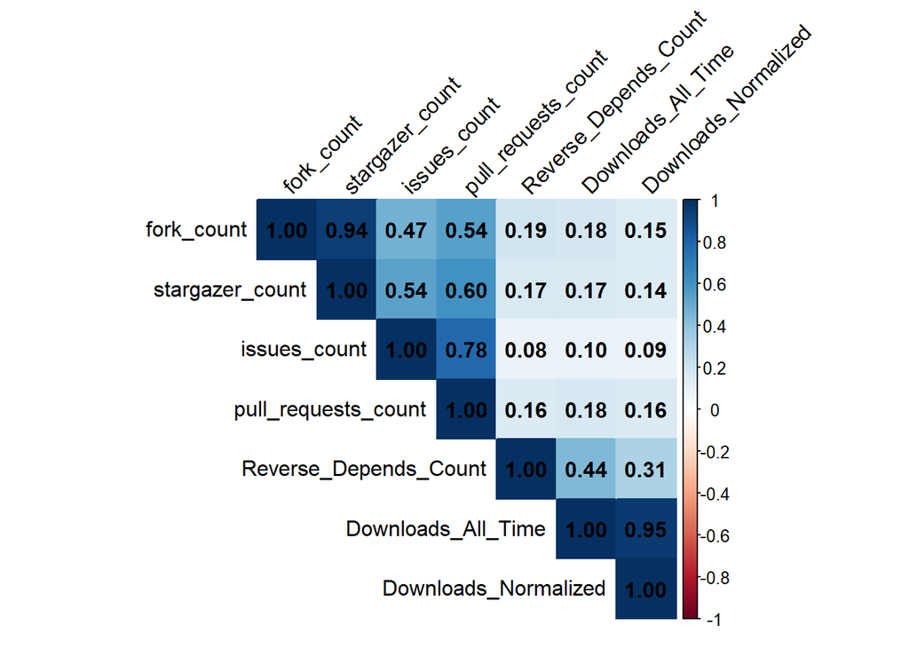

```r
All_Impacts <- cran_repos %>%
  select(Downloads_All_Time, Downloads_Normalized, Reverse_Depends_Count, fork_count, stargazer_count,
         issues_count, pull_requests_count, issues_count)

All_Impacts <- na.omit(All_Impacts)

Corr <- cor(All_Impacts)

corrplot(Corr, method = "color", type = "upper", order = "hclust",
         addCoef.col = "black", # Add correlation coefficients
         tl.col="black", tl.srt=45)
```